# NLP_Project_Full_Code_Abebaw_updated

## **Problem Statement**

by Abebaw Masresha Nov 2024

### Business Context

The prices of the stocks of companies listed under a global exchange are influenced by a variety of factors, with the company's financial performance, innovations and collaborations, and market sentiment being factors that play a significant role. News and media reports can rapidly affect investor perceptions and, consequently, stock prices in the highly competitive financial industry. With the sheer volume of news and opinions from a wide variety of sources, investors and financial analysts often struggle to stay updated and accurately interpret its impact on the market. As a result, investment firms need sophisticated tools to analyze market sentiment and integrate this information into their investment strategies.

### Problem Definition

With an ever-rising number of news articles and opinions, an investment startup aims to leverage artificial intelligence to address the challenge of interpreting stock-related news and its impact on stock prices. They have collected historical daily news for a specific company listed under NASDAQ, along with data on its daily stock price and trade volumes.

As a member of the Data Science and AI team in the startup, you have been tasked with analyzing the data, developing an AI-driven sentiment analysis system that will automatically process and analyze news articles to gauge market sentiment, and summarizing the news at a weekly level to enhance the accuracy of their stock price predictions and optimize investment strategies. This will empower their financial analysts with actionable insights, leading to more informed investment decisions and improved client outcomes.

### Data Dictionary

- `Date` : The date the news was released
- `News` : The content of news articles that could potentially affect the company's stock price
- `Open` : The stock price (in \$) at the beginning of the day
- `High` : The highest stock price (in \$) reached during the day
- `Low` : The lowest stock price (in \$) reached during the day
- `Close` : The adjusted stock price (in \$) at the end of the day
- `Volume` : The number of shares traded during the day
- `Label` : The sentiment polarity of the news content
  - 1: positive
  - 0: neutral
  - -1: negative

## **Installing Necessary Libraries**

```python
# Install the sentence-transformers library, which provides easy access to a variety of pre-trained transformer models.
# These models are optimized for creating high-quality sentence embeddings.
!pip install -U sentence-transformers -q

# Install the gensim library, a well-known toolkit for natural language processing that includes word embedding models such as Word2Vec.
!pip install -U gensim -q

# Install the transformers library, maintained by Hugging Face, for a wide range of pre-trained transformer-based models.
!pip install -U transformers -q

# Install tqdm, a Python package that provides progress bars to help track the installation process or model training progress.
!pip install -U tqdm -q
```

## Import the Necessary Libraries

```python
import pandas as pd
import numpy as np
import matplotlib.pyplot as plt
import seaborn as sns
import warnings
warnings.filterwarnings('ignore')
```

## **Loading the dataset**

```python
from google.colab import drive

try:
  # Force remount Google Drive to refresh the connection
  drive.mount('/content/drive', force_remount=True)  # Added force_remount=True
  print("Drive mounted successfully!")
except ValueError as e:
  print(f"Mount failed: {e}")
```

```
Drive mounted successfully!
```

```python
path='/content/drive/My Drive/AIMLTRAINING/collabdata/NLP/stock_news.csv'
df=pd.read_csv(path)
```

## **Data Overview**

```python
# Display basic information about the DataFrame
print("Data Information:")
print("="*30)
print(df.info())

# Show summary statistics for numerical columns
print("\nData Description:")
print("="*30)
print(df.describe().T)

# Display shape of the dataset (number of rows and columns)
print("\nDataset Shape:")
print("="*30)
print(f"Rows: {df.shape[0]}, Columns: {df.shape[1]}")

# Preview the first few rows of the dataset
print("\nFirst 5 Rows:")
print("="*30)
print(df.head())

# Check for any missing values in each column
print("\nMissing Values per Column:")
print("="*30)
print(df.isnull().sum())

# Count the number of duplicate rows in the dataset
print("\nNumber of Duplicate Rows:")
print("="*30)
print(df.duplicated().sum())
```

```
Data Information:
==============================
<class 'pandas.core.frame.DataFrame'>
RangeIndex: 349 entries, 0 to 348
Data columns (total 8 columns):
 #   Column  Non-Null Count  Dtype
---  ------  --------------  -----
 0   Date    349 non-null    object
 1   News    349 non-null    object
 2   Open    349 non-null    float64
 3   High    349 non-null    float64
 4   Low     349 non-null    float64
 5   Close   349 non-null    float64
 6   Volume  349 non-null    int64
 7   Label   349 non-null    int64
dtypes: float64(4), int64(2), object(2)
memory usage: 21.9+ KB
None

Data Description:
==============================
        count          mean           std           min           25%  \
Open    349.0  4.622923e+01  6.442817e+00  3.756750e+01  4.174000e+01
High    349.0  4.670046e+01  6.507321e+00  3.781750e+01  4.224500e+01
Low     349.0  4.574539e+01  6.391976e+00  3.730500e+01  4.148250e+01
Close   349.0  4.492632e+01  6.398338e+00  3.625413e+01  4.024691e+01
Volume  349.0  1.289482e+08  4.317031e+07  4.544800e+07  1.032720e+08
Label   349.0 -5.444126e-02  7.151192e-01 -1.000000e+00 -1.000000e+00

                 50%           75%           max
Open    4.597500e+01  5.070750e+01  6.681750e+01
High    4.602500e+01  5.085000e+01  6.706250e+01
Low     4.564000e+01  4.977750e+01  6.586250e+01
Close   4.459692e+01  4.911079e+01  6.480523e+01
Volume  1.156272e+08  1.511252e+08  2.444392e+08
Label   0.000000e+00  0.000000e+00  1.000000e+00

Dataset Shape:
==============================

```

[output cut: 16 more lines]

```
Missing Values per Column:
==============================
Date      0
News      0
Open      0
High      0
Low       0
Close     0
Volume    0
Label     0
dtype: int64

Number of Duplicate Rows:
==============================
0
```

## **Exploratory Data Analysis**

### Univariate Analysis

- Distribution of individual variables
- Compute and check the distribution of the length of news content

### **Date** Univariate Analysis

- Since the `Date` column is of object type, let's convert it to `datetime` for easier manipulation and analysis.

```python
#convert Date column into 'date' type
df['Date']=pd.to_datetime(df['Date'])


#Check the data type of "Date"
print(df['Date'].dtype)

#print sample
df.head()
```

```
datetime64[ns]
```

|  | Date | News | Open | High | Low | Close | Volume | Label |
| --- | --- | --- | --- | --- | --- | --- | --- | --- |
| 0 | 2019-01-02 | The tech sector experienced a significant dec... | 41.740002 | 42.244999 | 41.482498 | 40.246914 | 130672400 | -1 |
| 1 | 2019-01-02 | Apple lowered its fiscal Q1 revenue guidance ... | 41.740002 | 42.244999 | 41.482498 | 40.246914 | 130672400 | -1 |
| 2 | 2019-01-02 | Apple cut its fiscal first quarter revenue fo... | 41.740002 | 42.244999 | 41.482498 | 40.246914 | 130672400 | -1 |
| 3 | 2019-01-02 | This news article reports that yields on long... | 41.740002 | 42.244999 | 41.482498 | 40.246914 | 130672400 | -1 |
| 4 | 2019-01-02 | Apple's revenue warning led to a decline in U... | 41.740002 | 42.244999 | 41.482498 | 40.246914 | 130672400 | -1 |

```python
# Univariate analysis of the Date column
# Print basic information and key insights for the 'Date' column
print('Number of Unique dates: ', len(df['Date'].unique()))
print('Start and end date: ', df['Date'].min(), df['Date'].max())
print('Range of the date: ', df['Date'].max() - df['Date'].min())
print('Days with more than one record:', df['Date'].duplicated().sum())

# Print the top 5 days with the most records
print("Top 5 Days with the Most Records:")
print(df['Date'].value_counts().sort_values(ascending=False).head(10))
```

```
Number of Unique dates:  71
Start and end date:  2019-01-02 00:00:00 2019-04-30 00:00:00
Range of the date:  118 days 00:00:00
Days with more than one record: 278
Top 5 Days with the Most Records:
Date
2019-01-03    28
2019-01-30    17
2019-01-02    14
2019-04-17    12
2019-03-25    11
2019-01-15    11
2019-01-22    10
2019-01-07    10
2019-01-04    10
2019-01-08     9
Name: count, dtype: int64
```

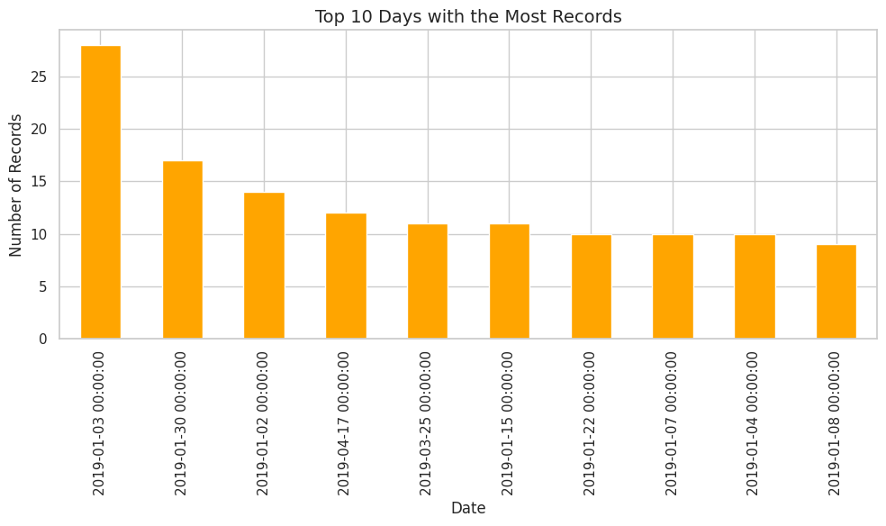

```python
# Group by Date and count the number of occurrences for each date
date_counts = df['Date'].value_counts().sort_values(ascending=False)

# Plotting a bar chart to visualize the top 10 days with the most records
plt.figure(figsize=(10, 6))
date_counts.head(10).plot(kind='bar', color='orange')
plt.title("Top 10 Days with the Most Records", fontsize=14)
plt.xlabel("Date", fontsize=12)
plt.ylabel("Number of Records", fontsize=12)
plt.xticks(rotation=90)
plt.tight_layout()
plt.show()
```

### Date Column Insights:

1. The dataset spans **118 days** (from January 2 to April 30, 2019) with **71 unique dates**, indicating non-uniform data collection over the period.
2. **January 3rd, 2019** has the highest number of records (28), suggesting significant events or noteworthy occurrences on that day.
3. A total of **278 records** correspond to **multiple entries per day**, pointing to frequent updates or recurring events being logged on certain days.

### **News** univariate Analysis

```python
from collections import Counter
from nltk.corpus import stopwords
import nltk
import pprint
df_news = pd.DataFrame()
# Calculate the length of each news article and create a new column 'news_length'
df_news['news_length'] = df['News'].apply(len)

# Show basic descriptive statistics for the 'news_length' column and print them in a readable format
print("Descriptive Statistics for 'news_length':")
print(df_news['news_length'].describe().to_string())

# Download the list of stopwords if not already downloaded
nltk.download('stopwords')

# Define the set of English stopwords to exclude common words from word count analysis
stop = set(stopwords.words('english'))

# Split news text into individual words, remove stop words, and count word frequencies
word_counts = Counter(
    word.lower() for text in df['News'] for word in text.split() if word.lower() not in stop
)

# Display the 10 most common words in the news articles with pretty print
print("\nTop 10 Most Common Words in News Articles:")
pprint.pprint(word_counts.most_common(10))
```

```
Descriptive Statistics for 'news_length':
count    349.000000
mean     311.237822
std       39.079467
min      110.000000
25%      290.000000
50%      315.000000
75%      336.000000
max      394.000000

Top 10 Most Common Words in News Articles:
[('apple', 152),
 ('due', 100),
 ('revenue', 69),
 ("apple's", 63),
 ('trade', 63),
 ('stock', 60),
 ('u.s.', 59),
 ('new', 51),
 ('reported', 47),
 ('company', 47)]
```

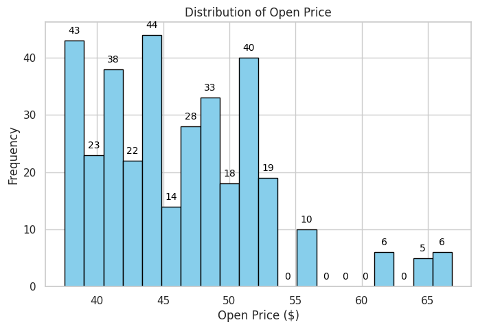

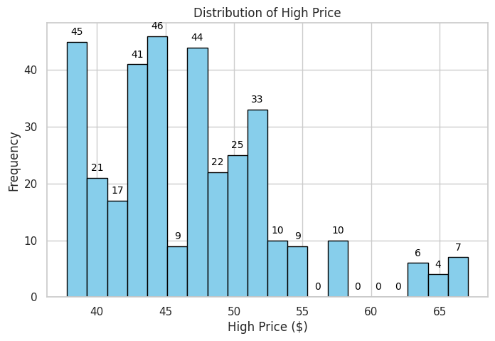

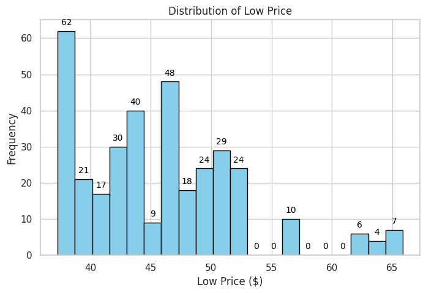

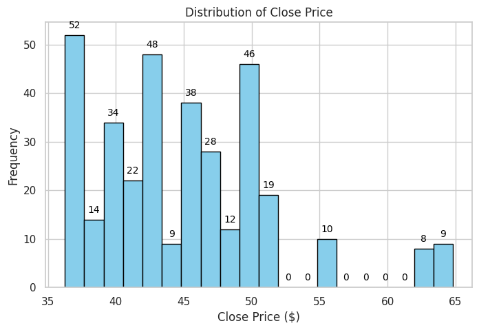

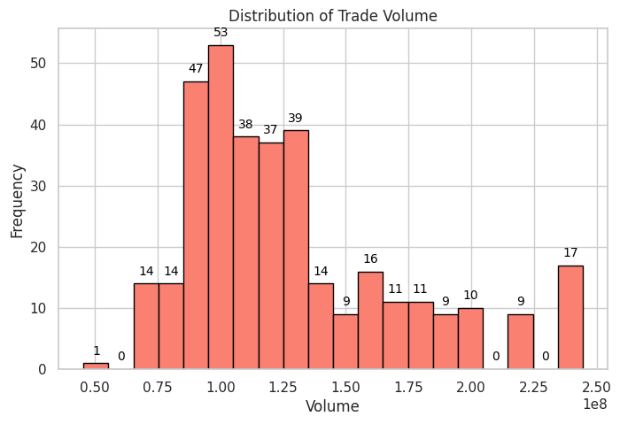

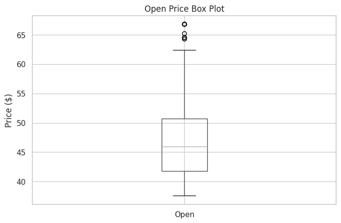

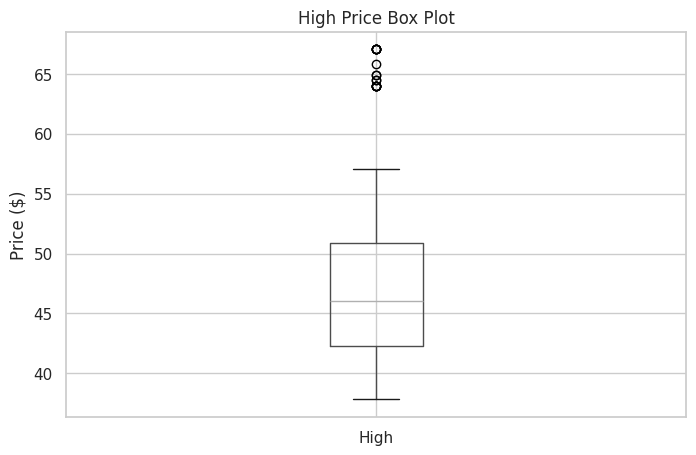

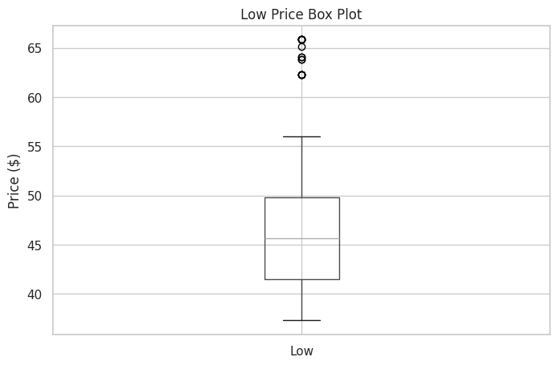

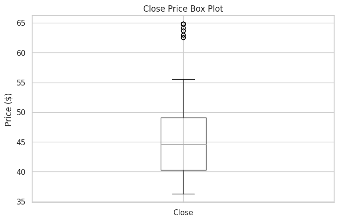

[figure not shown]

```python
import matplotlib.pyplot as plt
from collections import Counter
from nltk.corpus import stopwords
import nltk
import numpy as np

# Download stopwords if needed
nltk.download('stopwords')

# Define stop words
stop = set(stopwords.words('english'))

# # Summaries for the Stock Price and Volume Columns
# print("Descriptive Statistics for Stock Prices and Volume:")
# print(df[['Open', 'High', 'Low', 'Close', 'Volume']].describe().to_string())

# Histograms and Summary for each Stock Price Column
stock_price_columns = ['Open', 'High', 'Low', 'Close']
for col in stock_price_columns:
    # print(f"\nData Summary for {col}:")
    # print(df[col].describe().to_string())  # Print data summary

    # Plot histogram
    plt.figure(figsize=(8, 5))
    ax = df[col].hist(bins=20, color='skyblue', edgecolor='black')
    plt.title(f"Distribution of {col} Price")
    plt.xlabel(f"{col} Price ($)")
    plt.ylabel("Frequency")

    # Add frequency count on top of each bar
    for p in ax.patches:
        ax.annotate(f'{p.get_height():.0f}', (p.get_x() + p.get_width() / 2., p.get_height()),
                    ha='center', va='center', fontsize=10, color='black', xytext=(0, 10),
                    textcoords='offset points')

    plt.show()

# Volume Column Analysis
# print("\nData Summary for Volume:")
# print(df['Volume'].describe().to_string())  # Print data summary

# Histogram for Volume
plt.figure(figsize=(8, 5))
ax = df['Volume'].hist(bins=20, color='salmon', edgecolor='black')
plt.title("Distribution of Trade Volume")
plt.xlabel("Volume")
plt.ylabel("Frequency")

# Add frequency count on top of each bar
for p in ax.patches:
    ax.annotate(f'{p.get_height():.0f}', (p.get_x() + p.get_width() / 2., p.get_height()),
                ha='center', va='center', fontsize=10, color='black', xytext=(0, 10),
                textcoords='offset points')

plt.show()

# Box Plots for Stock Price Columns to Identify Outliers
for col in stock_price_columns:
    plt.figure(figsize=(8, 5))
    ax = df.boxplot(column=col)
    plt.title(f"{col} Price Box Plot")
    plt.ylabel("Price ($)")

    # Calculate the outliers using the IQR method
    Q1 = df[col].quantile(0.25)
    Q3 = df[col].quantile(0.75)
    IQR = Q3 - Q1
    lower_bound = Q1 - 1.5 * IQR
    upper_bound = Q3 + 1.5 * IQR

    # Find outliers
    outliers = df[(df[col] < lower_bound) | (df[col] > upper_bound)]
    # print(f"\nOutliers in {col}:")
    # print(outliers[[col]])

    plt.show()

# Sentiment Label Analysis
# print("\nSentiment Label Distribution:")
label_counts = df['Label'].value_counts()
# print(label_counts)

# Bar Chart for Sentiment Label Distribution
plt.figure(figsize=(6, 4))
ax = label_counts.plot(kind='bar', color=['green', 'gray', 'red'])
plt.title("Distribution of Sentiment Labels")
plt.xlabel("Sentiment Label")
plt.ylabel("Frequency")
plt.xticks(ticks=[0, 1, 2], labels=['Positive', 'Neutral', 'Negative'], rotation=0)

# Add counter at the top of each bar
for p in ax.patches:
    ax.annotate(f'{p.get_height():.0f}', (p.get_x() + p.get_width() / 2., p.get_height()),
                ha='center', va='center', fontsize=10, color='black', xytext=(0, 10),
                textcoords='offset points')

plt.show()
```

### **Insights for univariate analysis:**

**Open Price**:

- The average opening price is **46.23**, with a standard deviation of **6.44**, indicating moderate volatility in the stock’s opening price over the period.
- There are **outliers** at **66.82** and **64.33**, suggesting occasional price spikes that could be of interest for further analysis, as these prices are significantly higher than the 75th percentile of **50.71**.

**High Price**:

- The mean high price is **46.70**, and the **max price** is **67.06**, indicating that the stock occasionally peaks at higher values, possibly due to market events or high demand.
- Similar to the Open price, **outliers** are observed at **67.06** and **64.88**, signaling unusual market behavior during certain periods.

**Low Price**:

- The low price has an average value of **45.75**, with prices typically fluctuating between **41.48** and **49.78**.
- Outliers are visible at **65.86** and **62.29**, which are significantly above the typical range for low prices, suggesting these periods could involve significant price drops or market disruptions.

**Close Price**:

- The average closing price is **44.93**, slightly lower than the other price columns, indicating a potential downward trend or market correction toward the end of the trading session.
- Outliers are at **64.81** and **62.57**, with these values being much higher than the typical closing range of **49.11** and **40.25**, indicating rare spikes in the stock's closing value.

**Volume:**

1. The mean trading volume is **128.95 million** shares with a standard deviation of **43.17 million**, indicating substantial variation in the volume of trades over the period.
2. The minimum volume observed is **45.45 million**, while the maximum volume peaks at **244.44 million**, signaling periods of both low and very high trading activity, which may be linked to key events affecting stock prices.

**Sentiment Labels:**

1. The sentiment distribution shows that **170 instances** (about **49%**) are labeled as **neutral** (Label 0), which is the most common sentiment, reflecting periods of market stability.
2. The **negative sentiment** label (Label -1) appears in **99 instances**, showing a notable portion of periods associated with market declines or pessimism. Meanwhile, **positive sentiment** (Label 1) is less frequent, with **80 instances** (about **23%**), possibly reflecting periods of optimism or growth in the market.

### Bivariate Analysis

- Correlation
- Sentiment Polarity vs Price
- Date vs Price

**Note**: The above points are listed to provide guidance on how to approach bivariate analysis. Analysis has to be done beyond the above listed points to get maximum scores.

### 1. Correlation Analysis

- **Goal**: Examine correlations between numerical variables (e.g., Open, High, Low, Close, Volume) to understand how stock prices and trading volumes are interrelated.

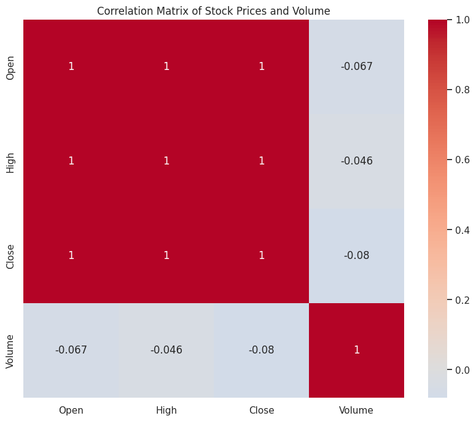

```python
#correlation matrix between numerical columns
corr_matrix=df[['Open','High','Close','Volume']].corr()
# print(corr_matrix)
plt.figure(figsize=(10,8))
sns.heatmap(corr_matrix,annot=True,cmap='coolwarm',center=0)
plt.title("Correlation Matrix of Stock Prices and Volume")
plt.show()
```

**Correlations insights**:

- The `Open`, `High`, and `Close` prices show a very strong positive correlation with each other (close to 1.0), indicating they move together closely on a daily basis.
- `Volume` has a very low negative correlation with `Open`, `High`, and `Close` prices (around -0.07 to -0.08), suggesting a weak inverse relationship between trading volume and price movements.

### 2. Sentiment Polarity vs. Price

- **Goal**: Determine how sentiment (represented by Label: positive, neutral, or negative) impacts stock prices.

[figure not shown]

```python
# Group data by 'Label' and calculate mean prices for each sentiment category
sentiment_price_summary = df.groupby('Label')[['Open', 'High', 'Low', 'Close']].mean()
# print(sentiment_price_summary)

# Visualize sentiment impact on closing price
plt.figure(figsize=(8, 5))
sns.barplot(data=sentiment_price_summary.reset_index(), x='Label', y='Close', palette="viridis")
plt.title("Average Closing Price by Sentiment Label")
plt.xlabel("Sentiment Label")
plt.ylabel("Average Closing Price ($)")
plt.xticks(ticks=[0, 1, 2], labels=['Positive', 'Neutral', 'Negative'])
plt.show()
```

**Sentiment Vs Price insights**:

- For sentiment label -1 (negative sentiment), `Close` prices are generally lower, suggesting that negative sentiment might correspond to reduced stock prices.
- Neutral sentiment (label 0) and positive sentiment (label 1) show higher average `Close` prices compared to negative sentiment, potentially indicating that neutral or positive news has a stabilizing or slightly positive effect on stock prices.

### 3. Date vs. Price

- **Goal**: Understand how stock prices fluctuate over time and identify any noticeable trends or seasonality.

```
Date range in the dataset:
Start date: 2019-01-02 00:00:00
End date: 2019-04-30 00:00:00


Summary statistics for 'Close' price:
count    349.000000
mean      44.926317
std        6.398338
min       36.254131
25%       40.246914
50%       44.596924
75%       49.110790
max       64.805229
Name: Close, dtype: float64
```

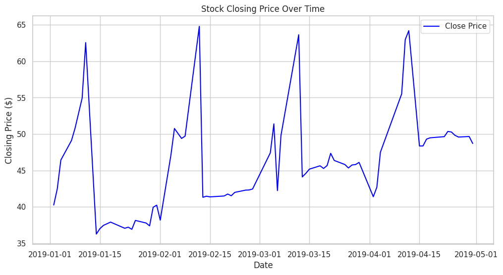

```python
# Print the date range in the data to understand the time span covered
print("Date range in the dataset:")
print(f"Start date: {df['Date'].min()}")
print(f"End date: {df['Date'].max()}")
print("\n")

# # Print the first and last few rows of the DataFrame to verify date ordering
# print("First few rows of the dataset:")
# print(df.head())
# print("\n")
# print("Last few rows of the dataset:")
# print(df.tail())
# print("\n")

# Calculate and print summary statistics for the 'Close' price
print("Summary statistics for 'Close' price:")
print(df['Close'].describe())
print("\n")

# Plot Close price over time
plt.figure(figsize=(12, 6))
plt.plot(df['Date'], df['Close'], color='blue', label='Close Price')
plt.title("Stock Closing Price Over Time")
plt.xlabel("Date")
plt.ylabel("Closing Price ($)")
plt.legend()
plt.show()
```

**Date Range and Price Summary**:

- The dataset covers a four-month period from January 2, 2019, to April 30, 2019, which provides a short-term perspective on stock price and sentiment trends.
- The average `Close` price over this period is approximately \$44.93, with a standard deviation of 6.4, showing moderate price volatility.
- The highest `Close` price is \$64.80, indicating some significant upward price movements within this time frame.

### 4. Sentiment Polarity vs. Volume

- **Goal**: Assess if trading volume differs across sentiment labels, as higher volumes may indicate heightened investor reaction to certain types of news.

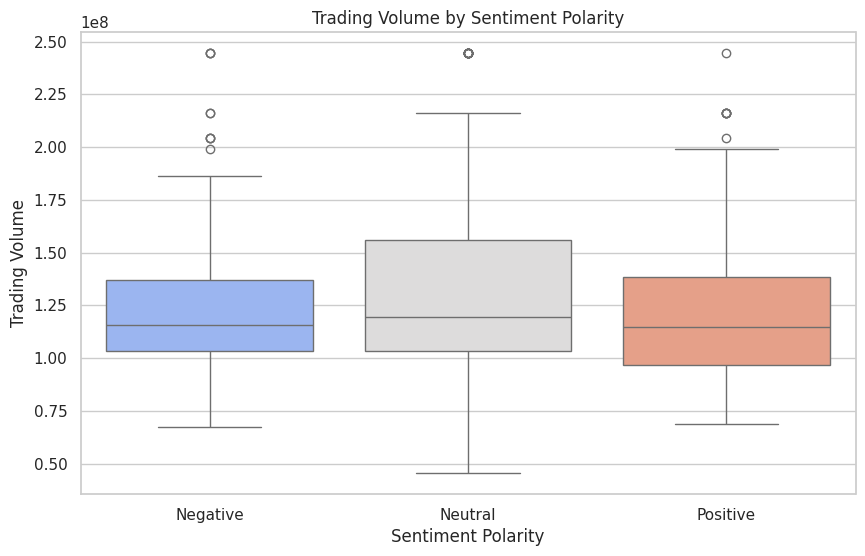

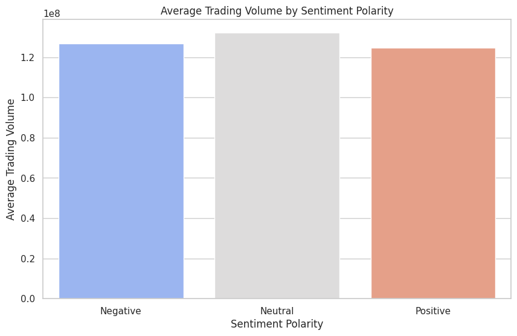

```python
import pandas as pd
import seaborn as sns
import matplotlib.pyplot as plt

# Print basic statistics for trading volume by sentiment polarity
# print("Summary Statistics for Trading Volume by Sentiment Polarity:\n")
volume_stats = df.groupby('Label')['Volume'].describe()
# print(volume_stats)
# print("\nAverage Trading Volume for each Sentiment Label:\n")
# print(volume_stats['mean'])

# Set the style for the plots
sns.set(style="whitegrid")

# Boxplot: Volume vs Sentiment Polarity
plt.figure(figsize=(10, 6))
sns.boxplot(data=df, x='Label', y='Volume', palette="coolwarm")
plt.title("Trading Volume by Sentiment Polarity")
plt.xlabel("Sentiment Polarity")
plt.ylabel("Trading Volume")
plt.xticks([0, 1, 2], ["Negative", "Neutral", "Positive"])
plt.show()

# Bar Plot: Average Volume by Sentiment Polarity
volume_by_sentiment = df.groupby('Label')['Volume'].mean().reset_index()
plt.figure(figsize=(10, 6))
sns.barplot(data=volume_by_sentiment, x='Label', y='Volume', palette="coolwarm")
plt.title("Average Trading Volume by Sentiment Polarity")
plt.xlabel("Sentiment Polarity")
plt.ylabel("Average Trading Volume")
plt.xticks([0, 1, 2], ["Negative", "Neutral", "Positive"])
plt.show()
```

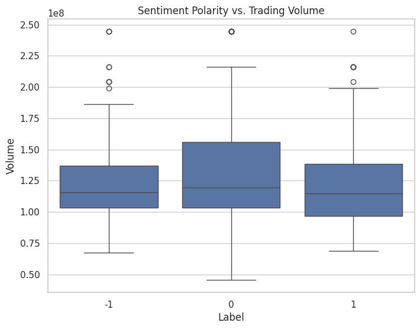

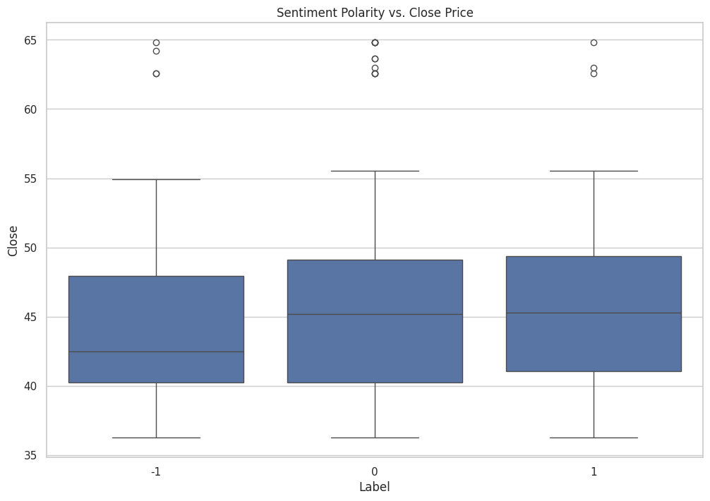

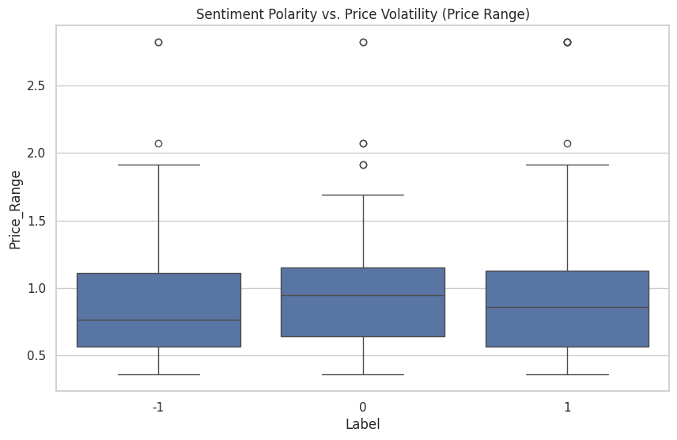

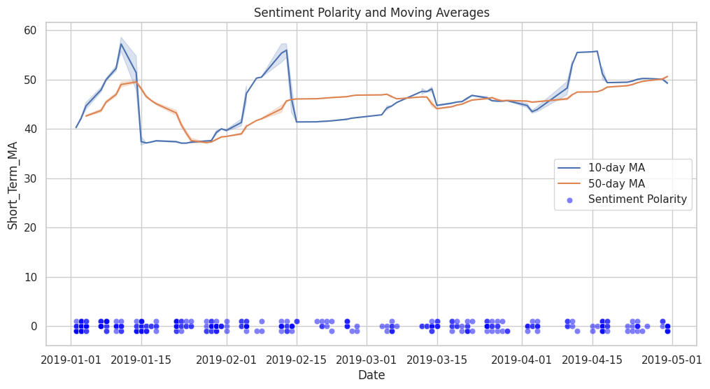

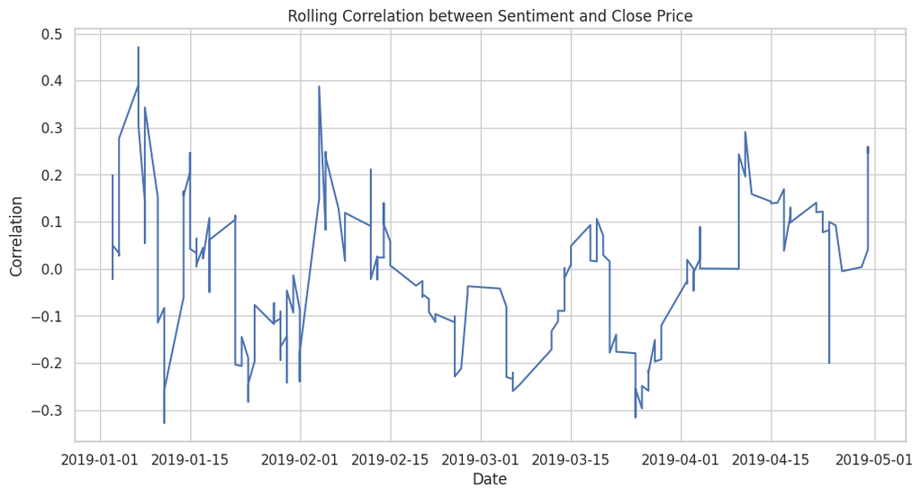

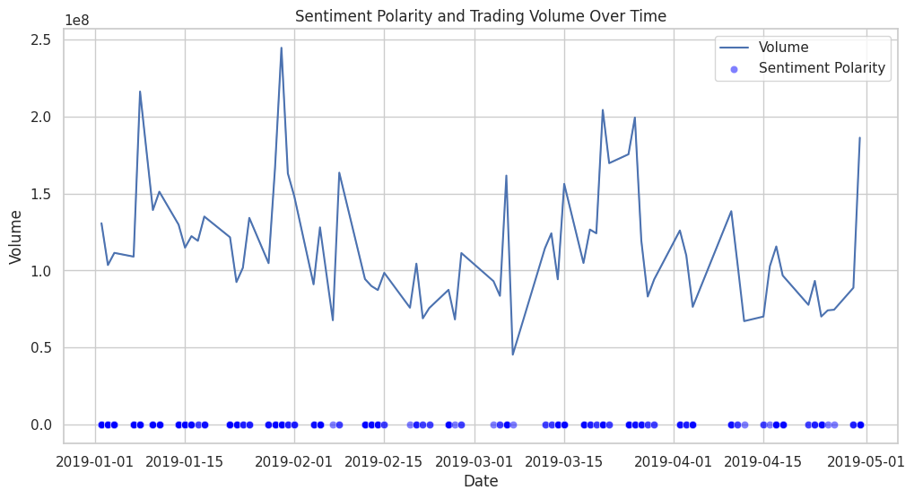

```
Average Trading Volume by Sentiment Label:
Label
-1    1.268821e+08
 0    1.321492e+08
 1    1.247030e+08
Name: Volume, dtype: float64

Correlation between Sentiment and Close Price:
          Label     Close
Label  1.000000  0.060144
Close  0.060144  1.000000
```

```python
# Additional Feature Calculations
df['Price_Range'] = df['High'] - df['Low']  # Price volatility (High - Low)
df['Short_Term_MA'] = df['Close'].rolling(window=10).mean()  # Short-term moving average
df['Long_Term_MA'] = df['Close'].rolling(window=50).mean()  # Long-term moving average

# Summary Statistics for Volume by Sentiment Polarity
# print("\nSummary Statistics for Trading Volume by Sentiment Polarity:")
# print(df.groupby('Label')['Volume'].describe())

# Sentiment Polarity vs Trading Volume Boxplot
plt.figure(figsize=(8, 6))
sns.boxplot(x='Label', y='Volume', data=df)
plt.title('Sentiment Polarity vs. Trading Volume')
plt.show()

# Sentiment Polarity vs Close Price Boxplot
plt.figure(figsize=(12, 8))
sns.boxplot(x='Label', y='Close', data=df)
plt.title('Sentiment Polarity vs. Close Price')
plt.show()

# Sentiment Polarity vs Price Volatility (Price Range)
plt.figure(figsize=(10, 6))
sns.boxplot(x='Label', y='Price_Range', data=df)
plt.title('Sentiment Polarity vs. Price Volatility (Price Range)')
plt.show()

# Sentiment Polarity and Moving Averages Plot
plt.figure(figsize=(12, 6))
sns.lineplot(x='Date', y='Short_Term_MA', data=df, label='10-day MA')
sns.lineplot(x='Date', y='Long_Term_MA', data=df, label='50-day MA')
sns.scatterplot(x='Date', y='Label', data=df, label='Sentiment Polarity', color='blue', alpha=0.5)
plt.title('Sentiment Polarity and Moving Averages')
plt.show()

# Rolling Correlation between Sentiment and Close Price
df['Rolling_Correlation'] = df['Label'].rolling(window=30).corr(df['Close'])
plt.figure(figsize=(12, 6))
plt.plot(df['Date'], df['Rolling_Correlation'], label='Rolling Correlation')
plt.title('Rolling Correlation between Sentiment and Close Price')
plt.xlabel('Date')
plt.ylabel('Correlation')
plt.show()

# Sentiment Polarity vs Trading Volume and Close Price Over Time
plt.figure(figsize=(12, 6))
sns.lineplot(x='Date', y='Volume', data=df, label='Volume')
sns.scatterplot(x='Date', y='Label', data=df, color='blue', alpha=0.5, label='Sentiment Polarity')
plt.title('Sentiment Polarity and Trading Volume Over Time')
plt.show()

# Additional Summary for Insights
print("\nAverage Trading Volume by Sentiment Label:")
print(df.groupby('Label')['Volume'].mean())

print("\nCorrelation between Sentiment and Close Price:")
print(df[['Label', 'Close']].corr())
```

## **Data Preprocessing**

**Split the Target Variable and Predictors**

```python
# Assuming 'df' is your DataFrame containing the data
X = df.drop(columns=['Label'])  # Predictors
y = df['Label']                 # Target variable
```

**Split the Data into Train, Validation, and Test Sets**

- Splitting the data helps to ensure the model is trained, validated, and tested on separate portions of the data.

```python
from sklearn.model_selection import train_test_split

# Split data into training and temporary (for validation and test) sets
X_train, X_temp, y_train, y_temp = train_test_split(X, y, test_size=0.3, random_state=42)

# Split the temporary set into validation and test sets
X_val, X_test, y_val, y_test = train_test_split(X_temp, y_temp, test_size=0.5, random_state=42)
```

```python
#copy the original
X_train_orig=X_train.copy()
X_val_orig=X_val.copy()
X_test_orig=X_test.copy()
```

**Preprocessing the Text Data**

- Preprocessing involves tokenization, lowercasing, removing stopwords, punctuation, and stemming/lemmatization. This ensures that the model gets clean and meaningful inputs.

```python
import nltk
import re
from nltk.corpus import stopwords
from nltk.stem import WordNetLemmatizer
from sklearn.feature_extraction.text import ENGLISH_STOP_WORDS

# Download required NLTK resources
nltk.download('stopwords')
nltk.download('wordnet')

# Initialize lemmatizer and stopwords
lemmatizer = WordNetLemmatizer()
stop_words = set(stopwords.words('english')).union(set(ENGLISH_STOP_WORDS))

# Preprocess text function
def preprocess_text(text):
    text = re.sub(r'\W', ' ', str(text))  # Remove non-alphanumeric characters
    text = text.lower()  # Convert to lowercase
    text = re.sub(r'\s+', ' ', text)  # Remove extra spaces
    text = [lemmatizer.lemmatize(word) for word in text.split() if word not in stop_words]
    return ' '.join(text)

# Apply preprocessing to news articles
X_train['processed_news'] = X_train['News'].apply(preprocess_text)
X_val['processed_news'] = X_val['News'].apply(preprocess_text)
X_test['processed_news'] = X_test['News'].apply(preprocess_text)
```

```python
#copy the preprossed data
X_train_prepro=X_train.drop(columns=['News'])
X_val_prepro= X_val.drop(columns=['News'])
X_test_prepro= X_test.drop(columns=['News'])
```

```python
X_train_prepro.sample(3)
```

|  | Date | Open | High | Low | Close | Volume | Price_Range | Short_Term_MA | Long_Term_MA | Rolling_Correlation | processed_news |
| --- | --- | --- | --- | --- | --- | --- | --- | --- | --- | --- | --- |
| 271 | 2019-03-25 | 47.877499 | 47.994999 | 46.650002 | 45.813015 | 175381200 | 1.344997 | 45.869085 | 46.026072 | -0.243548 | viacom stock surged 8 04 premarket trade monda... |
| 97 | 2019-01-15 | 37.567501 | 38.347500 | 37.512501 | 36.996128 | 114843600 | 0.834999 | 36.847729 | 47.772896 | 0.121916 | verizon announced offer free apple music subsc... |
| 186 | 2019-02-12 | 66.817497 | 67.062500 | 65.862503 | 64.805229 | 94487200 | 1.199997 | 54.630786 | 43.767792 | 0.139396 | apple facing resistance publication proposed n... |

```python
# Sample prints for Training Data
print("\nSample of Processed News from Training Set:")
print(X_train['processed_news'].head(3))

# Sample prints for Validation Data
print("\nSample of Processed News from Validation Set:")
print(X_val['processed_news'].head(3))

# Sample prints for Test Data
print("\nSample of Processed News from Test Set:")
print(X_test['processed_news'].head(3))
```

```
Sample of Processed News from Training Set:
139    apple release software patch week fix facetime...
79     green dot gdot bank holding company wide distr...
116    foxconn world largest contract manufacturer ap...
Name: processed_news, dtype: object

Sample of Processed News from Validation Set:
323    effort address eu antitrust concern avoid pena...
126    2018 google facebook broke previous record ann...
82     apple reportedly set release new iphone model ...
Name: processed_news, dtype: object

Sample of Processed News from Test Set:
294    response deadly mosque shooting christchurch a...
94     tuesday trading dow p 500 nasdaq rose tech sto...
76     federal reserve chairman jerome powell maintai...
Name: processed_news, dtype: object
```

## **Word Embeddings**

- In this section, we will use three embedding techniques: Word2Vec, GloVe, and Sentence Transformer.

**Tokenization**

```python
import nltk
nltk.download('punkt')
nltk.download('punkt_tab')

from nltk.tokenize import word_tokenize

# split the text data into tokens (words) using NLTK's word_tokenize
X_train['tokenized'] = X_train['processed_news'].apply(word_tokenize)
X_val['tokenized'] = X_val['processed_news'].apply(word_tokenize)
X_test['tokenized'] = X_test['processed_news'].apply(word_tokenize)
```

```python
#sample of a tokenized news
X_train['tokenized'][0]
```

```
['tech',
 'sector',
 'experienced',
 'significant',
 'decline',
 'aftermarket',
 'following',
 'apple',
 'q1',
 'revenue',
 'warning',
 'notable',
 'supplier',
 'including',
 'skyworks',
 'broadcom',
 'lumentum',
 'qorvo',
 'tsmc',
 'saw',
 'stock',
 'drop',
 'response',
 'apple',
 'downward',
 'revision',
 'revenue',
 'expectation',
 'quarter',
 'previously',
 'announced',
 'january']
```

**1. Word2Vec**

- Word2Vec is a technique to map words into continuous vector representations based on their context in a corpus of text

```python
from gensim.models import Word2Vec

# 1. Trained a Word2Vec model on the tokenized training data to learn word embeddings
 # (vector representations of words).
model_w2v = Word2Vec(sentences=X_train['tokenized'], vector_size=100, window=5, min_count=1, workers=4)

# Get the word vectors for the training set (average of word vectors for each document)
def get_word2vec_embeddings(tokens):
    embeddings = [model_w2v.wv[word] for word in tokens if word in model_w2v.wv]
    if embeddings:
        return np.mean(embeddings, axis=0)
    else:
        return np.zeros(model_w2v.vector_size)

# 2. Apply the model to transform each document into a vector by averaging the embeddings of the words in the document.
X_train['w2v_embeddings'] = X_train['tokenized'].apply(get_word2vec_embeddings)
X_val['w2v_embeddings'] = X_val['tokenized'].apply(get_word2vec_embeddings)
X_test['w2v_embeddings'] = X_test['tokenized'].apply(get_word2vec_embeddings)
```

```python
# Sample of 10 Word2Vec embeddings (first 10 values) from the training set
print("Sample of Word2Vec embeddings from the training data (first 10 values):")
print(X_train['w2v_embeddings'].head(1).apply(lambda x: x[:10]).to_list())

# Sample of 10 Word2Vec embeddings (first 10 values) from the validation set
print("\nSample of Word2Vec embeddings from the validation data (first 10 values):")
print(X_val['w2v_embeddings'].head(1).apply(lambda x: x[:10]).to_list())

# Sample of 10 Word2Vec embeddings (first 10 values) from the test set
print("\nSample of Word2Vec embeddings from the test data (first 10 values):")
print(X_test['w2v_embeddings'].head(1).apply(lambda x: x[:10]).to_list())

# Print size of the embedding vector
print("\nSize of the Word2Vec embedding vector:", len(X_train['w2v_embeddings'][0]))
```

```
Sample of Word2Vec embeddings from the training data (first 10 values):
[array([-5.1663750e-07,  4.0142986e-04, -5.0397724e-04,  1.4924245e-04,
       -2.6981873e-03, -4.7980705e-03, -4.3610815e-04,  4.6414053e-03,
       -2.0459502e-03, -2.4506988e-03], dtype=float32)]

Sample of Word2Vec embeddings from the validation data (first 10 values):
[array([ 3.22145252e-06,  8.32109654e-04, -4.68152080e-04,  1.09590546e-04,
       -1.76540139e-04, -2.84064608e-03,  1.22412515e-03,  4.37084539e-03,
       -2.69356254e-03,  2.41760499e-04], dtype=float32)]

Sample of Word2Vec embeddings from the test data (first 10 values):
[array([ 0.00094754,  0.00123904,  0.00092721,  0.00107229,  0.00029023,
       -0.00236338,  0.00196078,  0.00588961, -0.00177558, -0.00055511],
      dtype=float32)]

Size of the Word2Vec embedding vector: 100
```

**2. GloVe**

- We are going to use a pre-trained GloVe embedding file: glove.6B.100d.txt. This file contains word embeddings (vector representations) for a vocabulary of 6 billion tokens and 100 dimensions per word. It is pre-trained on large corpora like Wikipedia and Common Crawl.

```python
# 1. Load pre-trained GloVe embeddings
def load_glove_embeddings(file_path):
    embeddings = {}
    with open(file_path, 'r', encoding='utf-8') as f:
        for line in f:
            values = line.split()
            word = values[0]
            vector = np.asarray(values[1:], dtype='float32')
            embeddings[word] = vector
    return embeddings

# Path to the GloVe embeddings file
glove_path = '/content/drive/My Drive/AIMLTRAINING/collabdata/NLP/glove.6B.100d.txt.word2vec'

# Load GloVe embeddings from the provided path
glove_embeddings = load_glove_embeddings(glove_path)

# 2. Get GloVe embeddings for the training set (average of word vectors for each document)
def get_glove_embeddings(tokens):
    embeddings = [glove_embeddings[word] for word in tokens if word in glove_embeddings]
    if embeddings:
        return np.mean(embeddings, axis=0)
    else:
        return np.zeros(100)  # 100 is the embedding size in this case

# Apply GloVe embeddings to training, validation, and test sets
X_train['glove_embeddings'] = X_train['tokenized'].apply(get_glove_embeddings)
X_val['glove_embeddings'] = X_val['tokenized'].apply(get_glove_embeddings)
X_test['glove_embeddings'] = X_test['tokenized'].apply(get_glove_embeddings)
```

```python
# Sample of 10 GloVe embeddings (first 10 values) from the training set
print("Sample of GloVe embeddings from the training data (first 10 values):")
print(X_train['glove_embeddings'].head(1).apply(lambda x: x[:10]).to_list())

# Sample of 10 GloVe embeddings (first 10 values) from the validation set
print("\nSample of GloVe embeddings from the validation data (first 10 values):")
print(X_val['glove_embeddings'].head(1).apply(lambda x: x[:10]).to_list())

# Sample of 10 GloVe embeddings (first 10 values) from the test set
print("\nSample of GloVe embeddings from the test data (first 10 values):")
print(X_test['glove_embeddings'].head(1).apply(lambda x: x[:10]).to_list())

# Print size of the embedding vector
print("\nSize of the GloVe embedding vector:", len(X_train['glove_embeddings'][0]))
```

```
Sample of GloVe embeddings from the training data (first 10 values):
[array([-0.2355218 , -0.15399148,  0.2321451 , -0.08738768,  0.23116264,
       -0.02294589,  0.04929372,  0.02788177,  0.35011098, -0.05694992],
      dtype=float32)]

Sample of GloVe embeddings from the validation data (first 10 values):
[array([ 0.0925689 ,  0.05582913,  0.20928647, -0.01490611,  0.31673223,
       -0.04683442, -0.09129284, -0.12588225,  0.10330238, -0.05580498],
      dtype=float32)]

Sample of GloVe embeddings from the test data (first 10 values):
[array([ 0.0247935 , -0.04340014,  0.03435344, -0.14558354,  0.22172922,
        0.16404966, -0.22509408,  0.05576809, -0.08693152,  0.23430263],
      dtype=float32)]

Size of the GloVe embedding vector: 100
```

**3. Sentence Transformer**

- Sentence Transformers provide embeddings for entire sentences or documents, rather than individual words, making them ideal for tasks like document classification.

```python
from sentence_transformers import SentenceTransformer

# Initialize the model
# The all-MiniLM-L6-v2 model is an all-round (all) model trained on a large and diverse dataset of over 1 billion training samples
# and generates state-of-the-art sentence embeddings of 384 dimensions.
model_st = SentenceTransformer('all-MiniLM-L6-v2')

# Get sentence embeddings for the training set
X_train['st_embeddings'] = X_train['processed_news'].apply(lambda x: model_st.encode(x))
X_val['st_embeddings'] = X_val['processed_news'].apply(lambda x: model_st.encode(x))
X_test['st_embeddings'] = X_test['processed_news'].apply(lambda x: model_st.encode(x))
```

```python
# Sample of 10 Sentence Transformer embeddings (first 10 values) from the training set
print("Sample of Sentence Transformer embeddings from the training data (first 10 values):")
print(X_train['st_embeddings'].head(1).apply(lambda x: x[:10]).to_list())

# Sample of 10 Sentence Transformer embeddings (first 10 values) from the validation set
print("\nSample of Sentence Transformer embeddings from the validation data (first 10 values):")
print(X_val['st_embeddings'].head(1).apply(lambda x: x[:10]).to_list())

# Sample of 10 Sentence Transformer embeddings (first 10 values) from the test set
print("\nSample of Sentence Transformer embeddings from the test data (first 10 values):")
print(X_test['st_embeddings'].head(1).apply(lambda x: x[:10]).to_list())

# Print size of the embedding vector
print("\nSize of the Sentence Transformer embedding vector:", len(X_train['st_embeddings'][0]))
```

```
Sample of Sentence Transformer embeddings from the training data (first 10 values):
[array([-0.05562647, -0.02658168,  0.06747977, -0.02941504,  0.04360861,
       -0.02283512, -0.02641184, -0.06447335, -0.11674816,  0.01315732],
      dtype=float32)]

Sample of Sentence Transformer embeddings from the validation data (first 10 values):
[array([-0.06666519, -0.00244162,  0.03156815, -0.09772199, -0.04536402,
        0.00090142,  0.02837085, -0.03335231, -0.02991523, -0.04460339],
      dtype=float32)]

Sample of Sentence Transformer embeddings from the test data (first 10 values):
[array([ 0.03646325,  0.02628933, -0.01396195, -0.02001473,  0.14940971,
        0.0651058 , -0.03416226, -0.07296445,  0.02236827,  0.0900825 ],
      dtype=float32)]

Size of the Sentence Transformer embedding vector: 384
```

## **Sentiment Analysis**

**Goal**

- The goal of this project is to develop an AI-driven sentiment analysis system that analyzes stock-related news to gauge market sentiment, supporting improved stock price predictions and optimized investment strategies for more informed, effective decision-making.

**Primary Metric Choice** - **F1-Score**

**Why F1-Score?**

- Given the three-class classification problem with an imbalanced dataset (170 neutral, 99 negative, and 80 positive labels), the F1-score is an ideal metric. It balances precision and recall, emphasizing the model's ability to correctly classify each sentiment label (positive, neutral, negative), while accounting for class imbalance.

**Complementary Metric: Accuracy**

**Why Accuracy?**

- Accuracy offers a quick overview of correctness but can be misleading in imbalanced data, where the model might favor the majority class (neutral). As such, accuracy can serve as a supplementary measure to provide a broader perspective but isn’t suitable as the primary metric.

**1. Basic Sentiment Analysis Using Word2Vec Embeddings**

```python
from sklearn.ensemble import RandomForestClassifier
from sklearn.metrics import classification_report
import numpy as np

# Extract features (Word2Vec embeddings) from X_train, X_val, and X_test
X_train_w2v = np.stack(X_train['w2v_embeddings'].values)
X_val_w2v = np.stack(X_val['w2v_embeddings'].values)
X_test_w2v = np.stack(X_test['w2v_embeddings'].values)

# Initialize the Random Forest classifier
model_w2v = RandomForestClassifier(random_state=42)

# Train the model
model_w2v.fit(X_train_w2v, y_train)

# Predict on training, validation, and test sets
y_train_pred = model_w2v.predict(X_train_w2v)
y_val_pred = model_w2v.predict(X_val_w2v)
y_test_pred = model_w2v.predict(X_test_w2v)

# Print classification report for each set
print("\nTraining Set Classification Report:")
print("-" * 40)
print(classification_report(y_train, y_train_pred))

print("\nValidation Set Classification Report:")
print("-" * 40)
print(classification_report(y_val, y_val_pred))

print("\nTest Set Classification Report:")
print("-" * 40)
print(classification_report(y_test, y_test_pred))
```

```
Training Set Classification Report:
----------------------------------------
              precision    recall  f1-score   support

          -1       1.00      1.00      1.00        68
           0       1.00      1.00      1.00       126
           1       1.00      1.00      1.00        50

    accuracy                           1.00       244
   macro avg       1.00      1.00      1.00       244
weighted avg       1.00      1.00      1.00       244


Validation Set Classification Report:
----------------------------------------
              precision    recall  f1-score   support

          -1       0.24      0.25      0.24        16
           0       0.41      0.58      0.48        24
           1       0.00      0.00      0.00        12

    accuracy                           0.35        52
   macro avg       0.22      0.28      0.24        52
weighted avg       0.26      0.35      0.30        52


Test Set Classification Report:
----------------------------------------
              precision    recall  f1-score   support

          -1       0.46      0.40      0.43        15
           0       0.45      0.90      0.60        20
           1       0.00      0.00      0.00        18

    accuracy                           0.45        53
   macro avg       0.30      0.43      0.34        53
weighted avg       0.30      0.45      0.35        53
```

**2. Basic Sentiment Analysis Using GloVe**

```python
from sklearn.ensemble import RandomForestClassifier
from sklearn.metrics import classification_report
import numpy as np

# Extract GloVe embeddings for training, validation, and test sets
X_train_glove = np.stack(X_train['glove_embeddings'].values)
X_val_glove = np.stack(X_val['glove_embeddings'].values)
X_test_glove = np.stack(X_test['glove_embeddings'].values)

# Initialize the Random Forest classifier
model_glove = RandomForestClassifier(random_state=42)

# Train the model
model_glove.fit(X_train_glove, y_train)

# Predict on training, validation, and test sets
y_train_pred = model_glove.predict(X_train_glove)
y_val_pred = model_glove.predict(X_val_glove)
y_test_pred = model_glove.predict(X_test_glove)

# Print classification report for each set
print("\nTraining Set Classification Report:")
print("-" * 40)
print(classification_report(y_train, y_train_pred))

print("\nValidation Set Classification Report:")
print("-" * 40)
print(classification_report(y_val, y_val_pred))

print("\nTest Set Classification Report:")
print("-" * 40)
print(classification_report(y_test, y_test_pred))
```

```
Training Set Classification Report:
----------------------------------------
              precision    recall  f1-score   support

          -1       1.00      1.00      1.00        68
           0       1.00      1.00      1.00       126
           1       1.00      1.00      1.00        50

    accuracy                           1.00       244
   macro avg       1.00      1.00      1.00       244
weighted avg       1.00      1.00      1.00       244


Validation Set Classification Report:
----------------------------------------
              precision    recall  f1-score   support

          -1       0.25      0.06      0.10        16
           0       0.48      0.96      0.64        24
           1       0.00      0.00      0.00        12

    accuracy                           0.46        52
   macro avg       0.24      0.34      0.25        52
weighted avg       0.30      0.46      0.33        52


Test Set Classification Report:
----------------------------------------
              precision    recall  f1-score   support

          -1       0.17      0.07      0.10        15
           0       0.38      0.90      0.54        20
           1       0.00      0.00      0.00        18

    accuracy                           0.36        53
   macro avg       0.18      0.32      0.21        53
weighted avg       0.19      0.36      0.23        53
```